# Lab1: Getting started with R and Studio

Jiaxin Chen

1/29/2019

### Difference between R-GUI and RStudio

- R-GUI is a simply graphical user interface
- RStudio is an Integrated Development Environment (IDE)
  - It is much more than a simple GUI
  - It provides a nice working environment and development framework

### R as a scientific calculator

#### First contact with the R console

If you have never used software in which you have to type commands and code, our best suggestion is that you begin typing basic things in the **console**, using R as a scientific calculator.

For instance, consider the monthly bills of Leia (a stats undergrad student):

- cell phone $80
- transportation $20
- groceries $527
- gym $10
- rent $1500
- other $83

#### Your Turn

Make more assignments to create variables transportation, groceries, gym, rent, and other with their corresponding amounts.

```r
cell_phone <- 80
transportation <- 20
groceries <- 527
gym <- 10
rent <- 1500
other <- 83
```

Now that you have all the variables, create a total object with the sum of the expenses.

```r
total_expenses_month <- cell_phone + transportation + groceries + gym + rent + other
total_expenses_month
```

```
## [1] 2220
```

Assuming that Leia has the same expenses every month, how much would she spend during a school “semester”? (assume the semester involves five months).

```r
total_expenses_semester <- total_expenses_month * 5
total_expenses_semester
```

```
## [1] 11100
```

Maintaining the same assumption about the monthly expenses, how much would Leia spend during a school “year”? (assume the academic year is 10 months).

```r
total_expenses_year <- total_expenses_month * 10
total_expenses_year
```

```
## [1] 22200
```

#### Object Names

There are certain rules you have to follow when creating objects and variables. Object names cannot start with a digit and cannot contain certain other characters such as a comma or a space. You will be wise to adopt a convention for demarcating words in names.

#### Comments in R

All programming languages use a set of characters to indicate that a specifc part or lines of code are **comments**, that is, things that are not to be executed. R uses the hash or pound symbol # to specify comments. Any code to the right of # will not be executed by R.

#### Case Sensitive

R is case sensitive. This means that phone is not the same as `Phone` or `PHONE`

#### Your turn

Take your objects (i.e. variables) phone, transportation, groceries, gym, rent, and other and pass them inside the combine function c() to create a vector expenses.

Now, use the graphing function barplot() to produce a barchart of expenses:

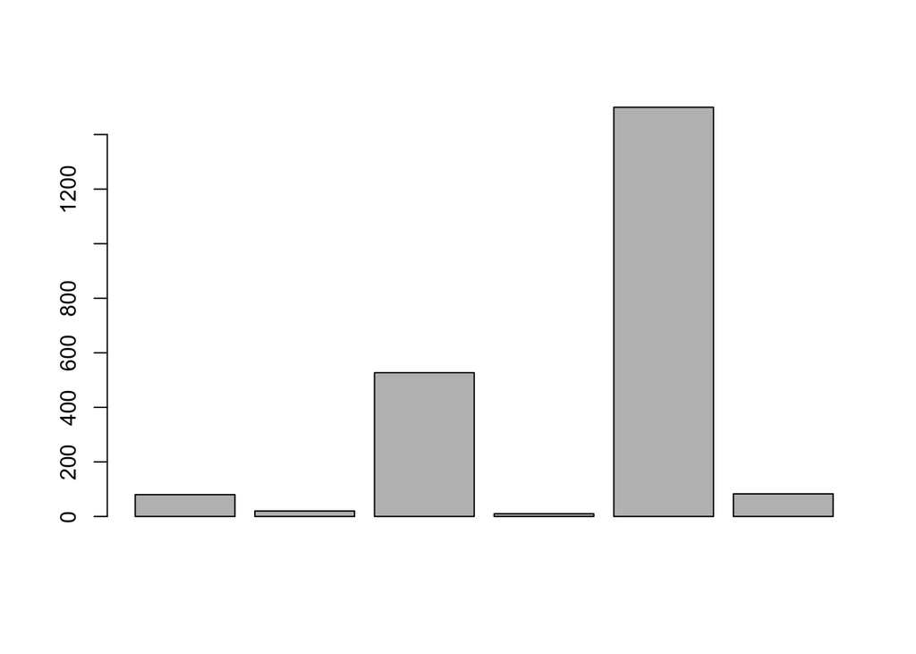

```r
expenses <- c(cell_phone, transportation, groceries, gym, rent, other)
barplot(expenses)
```

Find out how to use sort() to sort the elements in expenses, in order to produce a bar-chart with bars in decreasing order. Also, see if you can figure out how to display the names of the variables below each of the bars. Also optional, see if you can find out how to display the values of each variable at the top of each bar.

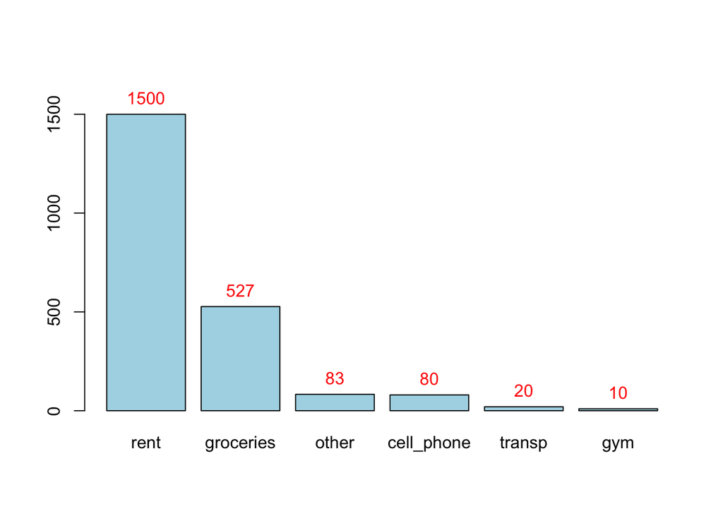

```r
expenses <- sort(expenses, decreasing = TRUE)

ylim <- c(0, 1.1 * max(expenses))

xx <- barplot(expenses, ylim = ylim, names.arg = c("rent", "groceries", "other", "cell_phone", "transp", "gym"), col = "light blue" )
text(x = xx, y = expenses, labels = expenses, pos = 3, cex = 1, col = "red")
```